**In this document I show how to perform simple analysis on all the buildings all over the planet and then how to present the results in a modern geo-mapping environment like Mapbox.**

# A Simple Analytic Pipeline: Make Your Own Colorful Maps

- 1- Use OpenStreetMap data at the scale of planet for each building (more than 300M buildings available from OSM: https://taginfo.openstreetmap.org/keys/building)
- 2- Qualify each building based on more than 160 categories of resources/activities (Points of Interests,POIs) around each building
- 3- Create a large vector tile (A modern data format for large spatial data sets)
- 4- Upload the vector tile to Mapbox, style it and serve it for your web applications.
- 5- Use mapbox GL on the client side to integrate the maps into your web application.

#### Accesiblity to transport infrastructure

[figure not shown]

#### Accesiblity to different types of places of worship (e.g. churches, mosques, etc.)

[figure not shown]

#### Building footprint area (sqm)

[figure not shown]

#### Orientation of the building along the first main axis (between 0-180)

[figure not shown]

```python
import os
import warnings
warnings.filterwarnings("ignore")
import pandas as pd
import numpy as np
from matplotlib import pyplot as plt
pd.__version__
import sys
from scipy import stats
%matplotlib inline
import sys
from scipy import stats
import sklearn.neighbors as neighbors
```

# 1. Extract the buildings

## 1-1- get the *.osm.pbf files for the region you want

- OSM extracts from here: https://download.geofabrik.de/
- Take the *.osm.pbf file

## 1-2- Filter the layers that you want (e.g. commercial buildings)

### osmconvert

- first we need to convert the pbf files to osm files, using osmconvert
- convert .pbf or bz by https://wiki.openstreetmap.org/wiki/Osmconvert download the source
  - download it like this: wget -O - http://m.m.i24.cc/osmconvert.c | cc -x c - -lz -O3 -o osmconvert
- ./osmconvert netherlands-latest.osm.pbf >netherlands-latest.osm

### osmfilter

- good guide: https://journocode.com/2018/01/08/extract-geodata-openstreetmap-osmfilter/
- ./osmfilter netherlands-latest.osm --out-count=building |head
- ./osmfilter netherlands-latest.osm --keep="highway=primary =secondary waterway=river" >streets.osm
- ./osmfilter netherlands-latest.osm --keep=building=* -o=netherlands_building.osm
- ./osmfilter netherlands-latest.osm --keep="highway=primary =secondary waterway=river" >streets.osm
- ./osmfilter netherlands-latest.osm --keep="building=commercial =industrial =garages = warehouse =service =office =retail " -o=netherlands_building_commercial.osm

## 1-3- Convert *.osm to* .geojson

- GDAL is installed in ogr conda environment
- ogr2ogr -f GeoJSON netherlands_building.geojson netherlands_building.osm multipolygons
- ogr2ogr -f GeoJSON netherlands_building_commercial.geojson netherlands_building_commercial.osm multipolygons
- Tips: https://gis.stackexchange.com/questions/22788/how-do-you-convert-osm-xml-to-geojson/69622#69622

# Important

**If you want to do it for the whole planet and all the countries, you might need more efficient ways of data processing. For example, we need to split the geojson files to smaller ones. For that goal, just use libraries such as https://github.com/woodb/geojsplit**

# 2. Calculate different geometric features from the Geojson files of the buildings, one by one

- **The ideas is simple: Open each building as a polygon (multipolygons) using libraries like Fiona ans Shapely and easily calculate features such as:**
  - Coordinates for the center of the buildings
  - Area of the footprint of each building
  - Number of corners in each building footprint
  - height of the buildings (not available for all)
  - Shape descriptors such as Fourier Descriptor
  - Orientation of each building (along the first and the second axis)
  - Anything else you can imagine to do with building footprints
- **The code below finally will save the building analytics of each country to CSV separate files**

```python
import glob
import os
path = 'path/json_splits/'
all_patches_names = []
counter = 0
for filename in glob.glob(os.path.join(path, '*.geojson')):
    all_patches_names.append(filename)
print ("number of geojson patches for ", region,": ", len(all_patches_names))



from shapely.ops import cascaded_union
import fiona
from shapely.geometry import Polygon
from shapely.geometry import MultiPolygon

all_areas = []
all_no_coords = []
all_xs = []
all_ys = []
all_osm_ids = []
all_building_types = []

for patch_no , buildings_path in enumerate(all_patches_names[:]):

    with fiona.open(buildings_path,) as f:
        crs = f.crs
        iterate = 0
        for rec in f:
            if rec['geometry']['type'] == 'MultiPolygon':
                polygons = MultiPolygon([Polygon(rec['geometry']['coordinates'][0][i]) for i in range(len(rec['geometry']['coordinates'][0]))])
                try:
                    areas = cascaded_union(polygons).area
                # areas = [polygons[i].area for i in range(len(polygons))]
                # if len(areas)>1:
                # 	areas =np.asarray(areas)
                # 	areas = np.sort(areas)
                # 	areas = areas[-1]-np.sum(areas[:-1])
                # else:
                # 	areas = areas[0]
                except:
                    print('does not work')
                    areas = 0

            no_coords = [len(polygons[i].exterior.coords)-1 for i in range(len(polygons))]
            no_coords = np.sum(no_coords)
            all_areas.append(areas)
            all_no_coords.append(no_coords)
            all_xs.append(polygons.centroid.xy[0][0])
            all_ys.append(polygons.centroid.xy[1][0])
            # all_osm_ids.append(str(rec['properties']['osm_id']))
            try:
                all_building_types.append(str(rec['properties']['building']))
            except:
                all_building_types.append(str('yes'))


            iterate = iterate +1
    if patch_no%20000==0:
        print ("patch number: ",patch_no,"polygon: ",iterate)
DF =pd.DataFrame()
DF['area'] = all_areas
DF['corners'] = all_no_coords
DF['x_center'] = all_xs
DF['y_center'] = all_ys
# DF['osm_id'] = all_osm_ids
DF['type'] = all_building_types

print ('corner analytics done')
import vaex

buildings_path = "path/buildings/"

csv_path = buildings_path+region+'-latest-building.csv'
DF.to_csv(path_or_buf=csv_path,index=False)
print ('CSV done')
```

# 3. Calculating building analytics based on distribution of different POIs around each building

## Here we assume we already have the building coordinates

## 3.1. Extracting POIs from OSM source of each country or just once for the whole planet

- There are some options, but I found this library (https://github.com/MorbZ/OsmPoisPbf) fantastic
- Read its instructions to see how you can play with different filters for POIs
- Also take a look at the POIs here: http://openpoimap.org/
- **We save the POIs to CSV files**

```python
#for planet
# JUST ONCE
import os
input_n  = 'path/planet-latest.osm.pbf'
output_n = input_n.replace('-latest.osm.pbf','-latest.pois.csv')
print ('java -Xmx8g -jar osmpois.jar --outputFile {} {}'.format(output_n,input_n))
os.system('java -Xmx32g -jar osmpois.jar --outputTags , --outputFile {} {}'.format(output_n,input_n))

convert the format of csvs to types
pois = pd.read_csv(output_n,sep='|',header=None).dropna()
pois.index = range(pois.shape[0])
pois.columns = ['type_code','OSM-ID','lat','lon']
pois['type_code'] = pois['type_code'].values[:].astype(int)

merged = pd.merge(pois,poi_type_met,on='type_code',how='outer').dropna()
#remove the redundant csvs
os.system('rm {}'.format(output_n))
output_n = output_n.replace('-latest.pois.csv','-latest-pois-with-types.csv')
merged.to_csv(output_n,index=False)
print (i,input_n.replace(path,''))
```

```python
# planet POis
planet_pois = pd.read_csv('path/planet-latest-pois-with-types.csv')
planet_pois.shape
```

```
(17324255, 5)
```

## What are the most frequent POIs?

```python
gb = planet_pois.groupby(by='type')
poi_groups = gb.count()
poi_groups = poi_groups.sort_values('lat',ascending=False)
top_poi_categories = poi_groups.head(40).index[:].values[:]
keys = [str(p) for p in poi_groups.index.values[:]]
poi_groups.head(40)
```

| type | type_code | OSM-ID | lat | lon |
| --- | --- | --- | --- | --- |
| TRANSPORT_BUSSTOP | 2052282 | 2052282 | 2052282 | 2052282 |
| POI_HAMLET | 1604846 | 1604846 | 1604846 | 1604846 |
| POI_VILLAGE | 1118308 | 1118308 | 1118308 | 1118308 |
| EDUCATION_SCHOOL | 893246 | 893246 | 893246 | 893246 |
| FOOD_RESTAURANT | 831912 | 831912 | 831912 | 831912 |
| POW_CHRISTIAN | 571165 | 571165 | 571165 | 571165 |
| LANDUSE_GRASS | 553204 | 553204 | 553204 | 553204 |
| SHOP_DEPARTMENTSTORE | 491491 | 491491 | 491491 | 491491 |
| POI_PEAK | 413650 | 413650 | 413650 | 413650 |
| SHOP_SUPERMARKET | 383413 | 383413 | 383413 | 383413 |
| SHOP_CONVENIENCE | 366246 | 366246 | 366246 | 366246 |
| ACCOMMO_HOTEL | 359290 | 359290 | 359290 | 359290 |
| FOOD_CAFE | 300180 | 300180 | 300180 | 300180 |
| FOOD_FASTFOOD | 295643 | 295643 | 295643 | 295643 |
| MONEY_BANK | 275154 | 275154 | 275154 | 275154 |
| TRANSPORT_FUEL | 268005 | 268005 | 268005 | 268005 |
| BARRIER_BLOCKS | 232645 | 232645 | 232645 | 232645 |
| SHOP_CLOTHES | 222314 | 222314 | 222314 | 222314 |
| HEALTH_PHARMACY | 203355 | 203355 | 203355 | 203355 |
| SHOP_HAIRDRESSER | 201112 | 201112 | 201112 | 201112 |
| EDUCATION_NURSERY | 200228 | 200228 | 200228 | 200228 |
| HEALTH_HOSPITAL | 197513 | 197513 | 197513 | 197513 |
| SHOP_CARREPAIR | 151722 | 151722 | 151722 | 151722 |
| POI_CRANE | 150621 | 150621 | 150621 | 150621 |
| FOOD_PUB | 139000 | 139000 | 139000 | 139000 |
| TOURIST_MEMORIAL | 132273 | 132273 | 132273 | 132273 |
| FOOD_BAR | 129554 | 129554 | 129554 | 129554 |
| TRANSPORT_STATION | 127295 | 127295 | 127295 | 127295 |
| AMENITY_PUBLICBUILDING | 124244 | 124244 | 124244 | 124244 |
| AMENITY_POSTOFFICE | 122802 | 122802 | 122802 | 122802 |
| SHOP_BAKERY | 121109 | 121109 | 121109 | 121109 |
| TOURIST_ATTRACTION | 117646 | 117646 | 117646 | 117646 |
| SHOP_DIY | 117376 | 117376 | 117376 | 117376 |
| POI_SUBURB | 112627 | 112627 | 112627 | 112627 |
| TOURIST_THEATRE | 100566 | 100566 | 100566 | 100566 |
| POI_TOWN | 96562 | 96562 | 96562 | 96562 |
| AMENITY_POLICE | 92262 | 92262 | 92262 | 92262 |
| LANDUSE_CONIFEROUSDECIDUOUS | 91837 | 91837 | 91837 | 91837 |
| EDUCATION_UNIVERSITY | 87475 | 87475 | 87475 | 87475 |
| SPORT_LEISURECENTER | 84305 | 84305 | 84305 | 84305 |

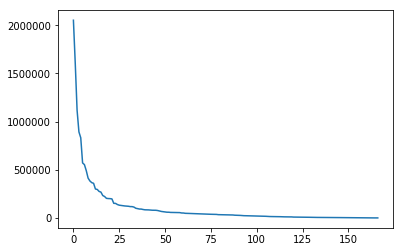

```python
plt.plot(poi_groups.type_code.values[:]);
```

## 3.2. Spatial query for each building

- This step (while not very efficient yet) is super simple. We open the building files and we just need the coordinates of the center of each building, previously calculated.
- Then for each POI type (e.g. TRANSPORT*BUSSTOP) or POI category (e.g. TRANSPORT**) we qualify the buildings.
- Here, we have two options:
  - 1-To set a radius around each building and count the POIs of the selected category in the given radius
  - 2- To calculate the distance to the closest POI of the selected category.
- I found the first approach more viable.

## Main categories of POIs

```python
poi_types = np.unique([x.split('_')[0] for x in poi_groups.index.values[:]])
poi_types
```

```
array(['ACCOMMO', 'AMENITY', 'BARRIER', 'EDUCATION', 'FOOD', 'HEALTH',
       'LANDUSE', 'MONEY', 'POI', 'POW', 'SHOP', 'SPORT', 'TOURIST',
       'TRANSPORT', 'WATER'],
      dtype='<U9')
```

```python
sel_types = []
sel_type = 'POW'
for c in keys:
    if sel_type in c:
        sel_types.append(c)
print (sel_types)
```

```
['POW_CHRISTIAN', 'POW_ISLAMIC', 'POW_UNKOWN', 'POW_BUDDHIST', 'POW_HINDU', 'POW_SHINTO', 'POW_JEWISH', 'POW_SIKH', 'POW_JAIN', 'POW_BAHAI']
```

```python
# CSV files of the building in each country
# One CSV file for the whole planet is super huge (>300M buildings)
import glob
import os
building_path = 'path/buildings/'

all_building_names = []
counter = 1
for filename in glob.glob(os.path.join(building_path, '*.csv')):
    all_building_names.append(filename)

print (len(all_building_names))
```

```
218
```

```python
chosen_r = 500
keys = [str(p) for p in poi_groups.index.values[:]]
```

## We run the following code for each of selected POIs

```python
sel_type = 'POW'
sel_types = ['POW_CHRISTIAN', 'POW_ISLAMIC', 'POW_BUDDHIST', 'POW_HINDU', 'POW_SHINTO', 'POW_JEWISH']
```

```python
#loop over every country and every POI type in each country --- > very slow.
# It's better to loop over buildings in each country and just on POI for planet
import sklearn.neighbors as neighbors

# we can do it per category or per type
based_on_poi_categoy='No'


Type_of_Search_for_POI = 'closest distance'
Type_of_Search_for_POI = 'radius search'

if based_on_poi_categoy=='Yes':
    pass

else:
    for count, key in enumerate(sel_types[:]):
        inds = list(np.where(planet_pois['type'].values[:]==key)[0])
        print (count,key, len(inds))
        sel_poi = planet_pois.loc[inds]
        coords_poi = sel_poi[['lat','lon']].values[:]

        if coords_poi.shape[0]>0:
            if Type_of_Search_for_POI == 'radius search':
                #Link to Sklearn: http://scikit-learn.org/stable/modules/generated/sklearn.neighbors.BallTree.html
                tree = neighbors.BallTree(np.radians(coords_poi), metric='haversine')
                # Here we look on a spatial radius around each buildings
                # And simply count the number of each POI in that distance
                ms_per_radian = 6371008.8
                r = chosen_r #in meters
                r_query = r/ms_per_radian
                for i , filename in enumerate(all_building_names[:]):
                    what_aspect = 'x_center','y_center'
                    buildings =  pd.read_csv(filename,usecols=what_aspect)
                    print (count,key,i,filename.replace(building_path,''),coords_poi.shape[0],buildings.shape[0])
                    buildings.columns= ['lon','lat']
                    buildings_with_neigh = buildings.copy()
                    if buildings_with_neigh.shape[0]>0:
                        buildings_with_neigh[key] = tree.query_radius(np.radians(buildings_with_neigh[['lat','lon']].values[:]), r=r_query, count_only=True)
                    else:
                        buildings_with_neigh[key] = np.zeros(buildings_with_neigh.shape[0])
                    buildings_with_neigh.to_csv(filename.replace('/buildings/','/OSM_pois_neigh/{}_'.format(key)),index=False)
        else:
            for i , filename in enumerate(all_building_names[:]):
                print (count,key,i,filename.replace(building_path,''),coords_poi.shape[0],buildings.shape[0])
                what_aspect = 'x_center','y_center'
                buildings =  pd.read_csv(filename,usecols=what_aspect)
                buildings.columns= ['lon','lat']
                buildings_with_neigh = buildings.copy()
                buildings_with_neigh[key] = np.zeros(buildings_with_neigh.shape[0])
                buildings_with_neigh.to_csv(filename.replace('/buildings/','/OSM_pois_neigh/{}_'.format(key)),index=False)
```

# 4. Converting the final CSV files to the maptiles using tippecanoe. This is a great library for huge data sets.

- https://github.com/mapbox/tippecanoe
- Read its instructions to find out the best way for your case.

### Next step, we will upload this tiles to mapbox for styling our own maps

```python
for key in sel_types:
    import glob
    import os

    # Path to qualified buildings for each POI
    path = 'path/OSM_pois_neigh/'
    sel_type = key
    all_csv_names = []
    counter = 1
    for filename in glob.glob(os.path.join(path, '*.csv')):
        #for each POI type and each country there is a unique CSV
        if sel_type in filename:
            all_csv_names.append(filename)

    print (len(all_csv_names))
    import os
    include = sel_type
    output_fn = 'path/tiles/'+sel_type+'.mbtiles'
    layer_n = sel_type
    input_fn =''
    for csv in all_csv_names:
        input_fn = input_fn +' '+ csv
    code  = 'tippecanoe -zg -o {} -l {} --include={} --drop-densest-as-needed --extend-zooms-if-still-dropping {}'.format(output_fn,layer_n,include,input_fn)
    os.system(code)
    print ('done')
```

# 5. Uploading the tiles to Mapbox

- Read the instructions here: https://www.mapbox.com/help/upload-curl/

# 6. Map styling

- Essentially, you need to know how to change the size and color of each point based on zoom level. For this you need to have a systematic procedure, based on the distribution of values and the number of points.
- Read this blog post: https://blog.mapbox.com/making-the-most-detailed-tweet-map-ever-b54da237c5ac

# 7. If you have your styled maps, the rest is to serve them to the client side.

- The best option is MapboxGL

## The final results can be found at [here](https://sevamoo.github.io/urban-modeling-at-scale/urbanmodeling.html)